# Using Time Data to forecast Train delay duration

## The goal

Here Pythonatic will be using train data, namely a train departure Delay Duration (measured in seconds), and a Date & Time label for that departure to forecast future delay durations.

### [SARIMA](https://en.wikipedia.org/wiki/Autoregressive_integrated_moving_average#Variations_and_extensions)

To make these forecasts Pythonatic will be using a model called SARIMA to make the delay forecasts. SARIMA stands for **S**easonal **A**uto-**R**egressive **I**ntegrated **M**oving **A**verage with factors and was built on previous simpler algorithms, ARMA which then enabled ARIMA to be built. These previous algorithms had less components.

### SARIMA components

Below are the algorithm's components summarized:

- **S**easonal means the model will try to find 'seasonal' patterns and use them to help in forecasting. It could for example be helpful in finding patterns such as average delays being longer during rush hours or in weekdays as opposed to weekends.
- **A**uto-**R**egressive means the model looks at the relationship between a given measurement and a few measurements close to it. This helps the model "see" how for example, previous delays might impact delays a a given amount of time later.
- **I**ntegrated makes use of differencing of raw observations (e.g. subtracting an observation from an observation at the previous time step) in order to make the time series stationary.
- **M**oving **A**verage uses the dependency between an observation and a residual error from a moving average model applied to lagged observations.

## Seasonality component

We decided to use SARIMA so we could investigate the seasonal patterns we noticed during data analysis, that some departure times seemed to have more potential for longer delays. That there was a visible difference between average delay durations during weekdays and during weekends.

### Rush hours

In this case we'll be investigating patterns noticed throughout each day. We've researched different official business hours and decided to label each datapoint with a number symbolizing the day slice that train was departing on.

We sliced each day in 5 different parts defined around business rush hours:

- 1 means the train was planning to depart during Early_Morning (00:00 - 05:59)
- 2 means the train was planning to depart during Morning_Rush_Hour (06:00 - 09:59)
- 3 means the train was planning to depart during Between_Rush_hours (10:00 - 14:59)
- 4 means the train was planning to depart during Afternoon_Rush_hour (15:00 - 18:59)
- 5 means the train was planning to depart during Night (19:00 - 24:00)

What we expect is that delays happen more often and for longer during our two defined Rush hours, Morning_Rush_Hour and Afternoon_Rush_hour

We can aggregate the delay data by these day slices to use it as our seasonality component with SARIMA. Later these day slices are also called Time_Group.

```python
#Data handling visualizing and Machine Learning
import numpy as np
import pandas as pd
import warnings
import itertools
import statsmodels
import statsmodels.api as sm
import matplotlib
import matplotlib.pyplot as plt
import seaborn as sns
import sklearn.metrics

#Utilities
import datetime
import random # used for random grid searching
from dateutil import parser #used for parsing datetime columns
from IPython.display import display
from IPython.display import Image #used for displaying images
import math # needed for the use of square root calculation during mean square error.

print('numpy version:', np.__version__)
print('pandas version:', pd.__version__)
print('statsmodels version:', statsmodels.__version__)
print('matplotlib version:', matplotlib.__version__)

%matplotlib inline
```

```
numpy version: 1.20.3
pandas version: 1.3.4
statsmodels version: 0.12.2
matplotlib version: 3.4.3
```

## Data Setup

For this part we'll be using data from the month of January in 2016 of train departures with end destination of "Schiphol Airport". Assuming this model is somewhat successful we can extend it to the whole of 2016 (assuming we have enough time to do so)

```python
# We import the data, it already includes previously discussed Time_Group day slices.
df = pd.read_csv('January_Schiphol_Time_Groups.csv')

df.shape
# As you can see just the month of January is 76315 rows
# The whole year of 2016 would slow down processing times down to hours or even days
```

```
(76315, 16)
```

#### Deleting unusable columns

```python
# Some columns are leftover from the time group making process and are deleted
df = df.drop(columns = ["Unnamed: 0", "Train_Departure_Planned_Time"])
```

#### Day slice numbers

```python
# The Time group was simply defined as the name of the day slice
# Later I want to create consecutive time groups so I add a number to make that process easier
df["Time_Group_Number"] = np.where(df['Time_Group'] == 'Early_Morning', 1,
                          np.where(df['Time_Group'] == 'Morning_Rush_Hour', 2,
                          np.where(df['Time_Group'] == 'Between_Rush_hours', 3,
                          np.where(df['Time_Group'] == 'Afternoon_Rush_hour', 4,
                          np.where(df['Time_Group'] == 'Night', 5, 0)))))
```

#### Data types

We convert some columns to their inteded data types, such as dates.

```python
# Here columns are converted to their intended data type, Dates are parsed and categorical data is converted to category
df['Train_Departure_Actual'] = df.apply(lambda row: parser.parse(row.Train_Departure_Actual), axis=1)
df['Train_Departure_Planned'] = df.apply(lambda row: parser.parse(row.Train_Departure_Planned), axis=1)
df["day_of_week"] = df["day_of_week"].astype("category")
df["Time_Group"] = df["Time_Group"].astype("category")
df["Train_Type"] = df["Train_Type"].astype("category")
df.dtypes
```

```
Station_Code                         object
Station_Name                         object
Train_Number                          int64
Train_Type                         category
Train_Company                        object
Train_Destination_Planned            object
Train_Destination_Actual             object
Train_Departure_Planned      datetime64[ns]
Train_Departure_Actual       datetime64[ns]
Train_Delay                         float64
MaxNumberOfStops                      int64
weekday                               int64
day_of_week                        category
Time_Group                         category
Time_Group_Number                     int32
dtype: object
```

#### Datetime indexing

I set a train departures planned time as the unique identifier for a row. This is required to use time-series models such as SARIMA

```python
df.set_index('Train_Departure_Planned', inplace=True)
df
```

| Train_Departure_Planned | Station_Code | Station_Name | Train_Number | Train_Type | Train_Company | Train_Destination_Planned | Train_Destination_Actual | Train_Departure_Actual | Train_Delay | MaxNumberOfStops | weekday | day_of_week | Time_Group | Time_Group_Number |
| --- | --- | --- | --- | --- | --- | --- | --- | --- | --- | --- | --- | --- | --- | --- |
| 2016-01-01 06:44:00 | HRL | Heerlen | 3528 | Intercity | NS | Schiphol Airport | Schiphol Airport | 2016-01-01 06:44:00 | 0.0 | 10 | 4 | Friday | Morning_Rush_Hour | 2 |
| 2016-01-01 06:48:00 | EHV | Eindhoven | 3524 | Intercity | NS | Schiphol Airport | Schiphol Airport | 2016-01-01 06:48:00 | 0.0 | 10 | 4 | Friday | Morning_Rush_Hour | 2 |
| 2016-01-01 07:00:00 | STD | Sittard | 3528 | Intercity | NS | Schiphol Airport | Schiphol Airport | 2016-01-01 07:00:00 | 0.0 | 10 | 4 | Friday | Morning_Rush_Hour | 2 |
| 2016-01-01 07:02:00 | DV | Deventer | 1624 | Intercity | NS | Schiphol Airport | Schiphol Airport | 2016-01-01 07:02:00 | 0.0 | 10 | 4 | Friday | Morning_Rush_Hour | 2 |
| 2016-01-01 07:09:00 | HT | 's-Hertogenbosch | 3524 | Intercity | NS | Schiphol Airport | Schiphol Airport | 2016-01-01 07:09:00 | 0.0 | 10 | 4 | Friday | Morning_Rush_Hour | 2 |
| ... | ... | ... | ... | ... | ... | ... | ... | ... | ... | ... | ... | ... | ... | ... |
| 2016-01-31 22:53:00 | HVS | Hilversum | 1684 | Intercity | NS | Schiphol Airport | Schiphol Airport | 2016-01-31 22:53:00 | 0.0 | 13 | 6 | Sunday | Night | 5 |
| 2016-01-31 23:10:00 | AMF | Amersfoort | 11686 | Intercity | NS | Schiphol Airport | Schiphol Airport | 2016-01-31 23:10:00 | 0.0 | 6 | 6 | Sunday | Night | 5 |
| 2016-01-31 23:40:00 | DVD | Duivendrecht | 11686 | Intercity | NS | Schiphol Airport | Schiphol Airport | 2016-01-31 23:40:00 | 0.0 | 6 | 6 | Sunday | Night | 5 |
| 2016-01-31 23:46:00 | ASDZ | Amsterdam Zuid | 11686 | Intercity | NS | Schiphol Airport | Schiphol Airport | 2016-01-31 23:46:00 | 0.0 | 6 | 6 | Sunday | Night | 5 |
| 2016-01-31 23:23:00 | HVS | Hilversum | 11686 | Intercity | NS | Schiphol Airport | Schiphol Airport | 2016-01-31 23:23:00 | 0.0 | 6 | 6 | Sunday | Night | 5 |

76315 rows × 14 columns

#### Negative delays

Previously we had found that some a very small number of trains had a negative delay. This meant they were leaving earlier than the planned time

Although this is real data we decided it was better to discard these exceptions lest the model's predictions become skewed and predict smaller delays

```python
# Here We filter those negative delays out
df.loc[df.Train_Delay < 0, 'Train_Delay'] = 0
```

### Consecutive day slices

I'll start by creating a column, "Time_Group_Day", that labels each day's slice differently. (i.e. instead of grouping all early mornings together I group early morning of day 1 separately from early morning of day 2.

Since there are 5 time groups per day and 31 days in january, this column will go from 1 to 155 (31*5).

- 1 Early_Morning (00:00 - 05:59)
- 2 Morning_Rush_Hour (06:00 - 09:59)
- 3 Between_Rush_hours (10:00 - 14:59)
- 4 Afternoon_Rush_hour (15:00 - 18:59)
- 5 Night (19:00 - 24:00)

In other words Day 1 slices will go from 1 to 5 like above, Day 2 slices will go from 6 to 10, Day 3 from 11 to 15, etc. This way the process would be usable for any month with any length, or the whole year.

```python
# Here I compute the consecutive day slices, using the index which is a train's planned departure time.
# I access the index's day component and multiply it by the number of desired slices, in this case 5.
# Then I add the number from the time group column to label it as the proper day slice
df['Time_Group_Day'] = df['Time_Group_Number'] + (df.index.day - df.index.day.min())*5
```

```python
# Early morning January 1st
df.loc[df['Time_Group_Day'] == 1]
```

| Train_Departure_Planned | Station_Code | Station_Name | Train_Number | Train_Type | Train_Company | Train_Destination_Planned | Train_Destination_Actual | Train_Departure_Actual | Train_Delay | MaxNumberOfStops | weekday | day_of_week | Time_Group | Time_Group_Number | Time_Group_Day |
| --- | --- | --- | --- | --- | --- | --- | --- | --- | --- | --- | --- | --- | --- | --- | --- |
| 2016-02-01 00:02:00 | RTD | Rotterdam Centraal | 1406 | Intercity | NS | Schiphol Airport | Schiphol Airport | 2016-02-01 00:02:00 | 0.0 | 2 | 0 | Monday | Early_Morning | 1 | 1 |

#### February still included

Here we noticed February was still included and January had no early morning slice for the first day.

As you can the above row is a train that is actually planning to departing in feburary and so should actually be after the very last day slice of January.

Let's change it to 156 manually bthen since it's chronologically after 155

```python
df.loc[df.Time_Group_Day == 1, 'Time_Group_Day'] = 156
```

#### Smaller dataframe made

We define a new dataframe with only the required columns:

- Planned Departure time
- Departure Delay duration (measured in seconds)
- The column labelling which day slice that departure was planned in (Time_Group_Day)

```python
dftiny = df[['Train_Delay', 'Time_Group_Number', 'Time_Group_Day']]
```

```python
dftiny
```

| Train_Departure_Planned | Train_Delay | Time_Group_Number | Time_Group_Day |
| --- | --- | --- | --- |
| 2016-01-01 06:44:00 | 0.0 | 2 | 2 |
| 2016-01-01 06:48:00 | 0.0 | 2 | 2 |
| 2016-01-01 07:00:00 | 0.0 | 2 | 2 |
| 2016-01-01 07:02:00 | 0.0 | 2 | 2 |
| 2016-01-01 07:09:00 | 0.0 | 2 | 2 |
| ... | ... | ... | ... |
| 2016-01-31 22:53:00 | 0.0 | 5 | 155 |
| 2016-01-31 23:10:00 | 0.0 | 5 | 155 |
| 2016-01-31 23:40:00 | 0.0 | 5 | 155 |
| 2016-01-31 23:46:00 | 0.0 | 5 | 155 |
| 2016-01-31 23:23:00 | 0.0 | 5 | 155 |

76315 rows × 3 columns

```python
pd.unique(dftiny.Time_Group_Day)
```

```
array([  2,   3,   4,   5,   6,   7,   8,   9,  10,  11,  12,  13,  14,
        15,  16,  17,  18,  19,  20,  21,  22,  23,  24,  25,  26,  27,
        28,  29,  30,  31,  32,  33,  34,  35,  36,  37,  38,  39,  40,
        41,  42,  43,  44,  45,  46,  47,  48,  49,  50,  51,  52,  53,
        54,  55,  56,  57,  58,  59,  60,  61,  62,  63,  64,  65,  66,
        67,  68,  69,  70,  71,  72,  73,  74,  75,  76,  77,  78,  79,
        80,  81,  82,  83,  84,  85,  86,  87,  88,  89,  90,  91,  92,
        93,  94,  95,  96,  97,  98,  99, 100, 101, 102, 103, 104, 105,
       106, 107, 108, 109, 110, 111, 112, 113, 114, 115, 116, 117, 118,
       119, 120, 121, 122, 123, 124, 125, 126, 127, 128, 129, 130, 131,
       132, 133, 134, 135, 136, 137, 138, 139, 140, 141, 142, 143, 144,
       145, 146, 147, 148, 149, 150, 151, 152, 153, 154, 155, 156],
      dtype=int64)
```

*Morning Rush hour* of January 1st is time group 2

. . . .

*Early Morning* of February 1st is time group 156

Note early morning of January is missing so there is no group 1

### Grouping data by day slice

```python
# To use aggregation functions I had to use the index as a column
dftiny['Train_Departure_Planned'] = dftiny.index
```

Here I want to group train departures by the day slice day they departed in.

However, I want to do different things with each column:

- I want to get the average delay by day slice to notice trends between slices but
- I want the median time as that time's the closest to all departures in that day slice

Because of this I defined a groupedby object below so I can apply different functions and merge the results.

```python
# I create the grouped object by grouping by consecutive day slice
grouped = dftiny.groupby(['Time_Group_Day'], as_index=False)
```

```python
# I get the median time per time group
grouped_time = grouped['Train_Departure_Planned'].median()
```

```python
# I calculate average delay per time group
grouped_delay = grouped['Train_Delay'].mean()
```

```python
# I merge above results
dfGroupie = grouped_time.merge(grouped_delay)
```

```python
# I drop the no longer necessary day slice label, as everything is already aggregated by departure time
dfGroupie.drop(columns='Time_Group_Day', inplace=True)
```

```python
# I set the planned departure as the index
dfGroupie.set_index('Train_Departure_Planned', inplace=True)
```

```python
# I end up dropping the 156 day slice because it was just one train departing at midnight in February
# it's not comparable to the rest of the groups which are many train departures grouped together
dfGroupie.drop(index='2016-02-01 00:02:00', inplace=True)
```

## Data visualization & analysis

```python
# The resulting dataframe contains 154 rows, here's how it looks like
dfGroupie
```

| Train_Departure_Planned | Train_Delay |
| --- | --- |
| 2016-01-01 08:36:00 | 58.196078 |
| 2016-01-01 12:27:00 | 15.819193 |
| 2016-01-01 16:53:00 | 33.414191 |
| 2016-01-01 20:40:00 | 128.553425 |
| 2016-01-02 04:41:00 | 49.087719 |
| ... | ... |
| 2016-01-31 04:27:00 | 31.684211 |
| 2016-01-31 08:30:00 | 56.927326 |
| 2016-01-31 12:42:30 | 58.666667 |
| 2016-01-31 16:59:00 | 79.473083 |
| 2016-01-31 20:46:00 | 135.812665 |

154 rows × 1 columns

```python
dfGroupie
```

| Train_Departure_Planned | Train_Delay |
| --- | --- |
| 2016-01-01 08:36:00 | 58.196078 |
| 2016-01-01 12:27:00 | 15.819193 |
| 2016-01-01 16:53:00 | 33.414191 |
| 2016-01-01 20:40:00 | 128.553425 |
| 2016-01-02 04:41:00 | 49.087719 |
| ... | ... |
| 2016-01-31 04:27:00 | 31.684211 |
| 2016-01-31 08:30:00 | 56.927326 |
| 2016-01-31 12:42:30 | 58.666667 |
| 2016-01-31 16:59:00 | 79.473083 |
| 2016-01-31 20:46:00 | 135.812665 |

154 rows × 1 columns

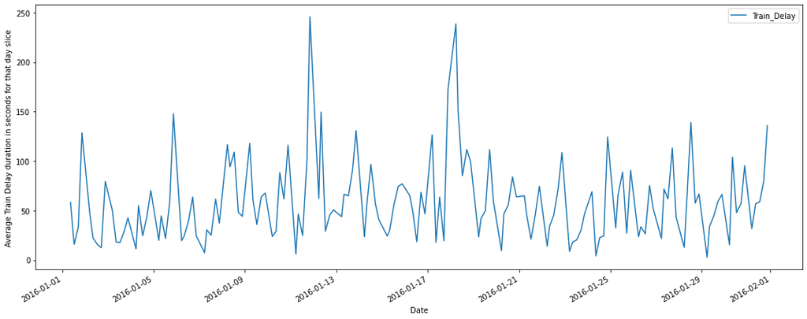

```python
# 154 rows for nearly every time group from January (Early_morning will be missing)
ax = dfGroupie.plot(figsize=(15, 6))

ax.set_xlabel('Date')
ax.set_ylabel('Average Train Delay duration in seconds for that day slice')

plt.show()
```

## Time Group visual patterns

As you can see above even averaging the delay duration by day slice still leaves it very spiky, and it is difficult to visualize any patterns exactly. We investigated how we could visualize the different day slices along the plot but it would have taken too long to implement.

- 1 Early_Morning (00:00 - 05:59)
- 2 Morning_Rush_Hour (06:00 - 09:59)
- 3 Between_Rush_hours (10:00 - 14:59)
- 4 Afternoon_Rush_hour (15:00 - 18:59)
- 5 Night (19:00 - 24:00)

However, knowing the first group is morning rush hour on January 1st already shows some patterns.

Just from these first few slices I cannot see a clearly repeating pattern, it just seems to spike sometimes. Perhaps with a better visualisation it would be possible to see some patterns.

```python
dfGroupie.describe()
```

|  | Train_Delay |
| --- | --- |
| count | 154.000000 |
| mean | 58.430715 |
| std | 41.159437 |
| min | 2.669291 |
| 25% | 26.613740 |
| 50% | 50.088431 |
| 75% | 72.106210 |
| max | 245.764957 |

## Delay duration ranges

As you can see in the table above, the average delay per slice ranges from 2.6 seconds to 245 seconds (or ~4 minutes).

These average delay durations are incredibly low, presumably because most trains simply have very little to no delay. Even the maximum delay of 4 minutes is unlikely to affect much beyond specific situations such as having a very tight time window to transfer between trains.

As much as this is unlikely to be of use for Ordina employees we will nevertheless attempt a forecast using this data below.

## SARIMA SETUP

Each of SARIMA's components are explicitly specified in the model as a parameter. A standard notation is used of ARIMA(p,d,q) where the parameters are substituted with integer values to quickly indicate the specific ARIMA model being used.

A value of 0 for any of these actually alters the exact model used. For example later in the code I will use a function called SARIMAX and simply not provide input for the e**X**ogenous part, this makes it into SARIMA. The same can be applied to the rest of the parameters to get models such as simply AR.

The parameters (order) of the ARIMA model are defined as follows:

- AR is p: The number of lag observations included in the model, also called the lag order.
- I is d: The number of times that the raw observations are differenced, also called the degree of differencing.
- MA is q: The size of the moving average window, also called the order of moving average.

Sarima then introduces seasonal versions (seasonal_order) of these along with a parameter defining seasonality:

- seasonal_p: The number of lag observations included in the model, also called the lag order.
- seasonal_d: The number of times that the raw observations are differenced, also called the degree of differencing.
- seasonal_q: The size of the moving average window, also called the order of moving average.
- seasonality: The number of rows between the observations it should compare. More specifically since we want to compare the first slice of a day to the first slice of the next day and the data aggregated by 5 types of time groups, there are 5 slices between the same type of group, so seasonality should be five.

```python
# Due to rush hours slicing each day in 5 and data being aggregated into those slices
# I want to compare for example monday morning to tuesday morning to wednesday morning
seasonality = 5
```

# Machine Learning - Time Series

## Hyperparameter Random Searching

To maximize my models accuracy I will select my model's hyper parameters by randomly generating them in batches and selecting the best out of those batches.

Below I define how big I want the batches to be, and how many batches I want there to be.

```python
# The inner loop will generate hyperparameter combinations and fit them this many times
batch_size = 20

# I will do this many batches and get the best scoring hyperparameter combination out of each one
batches = 5

print("I will generate and fit hyperparameters combinations in {} batches of {}, choosing the best one every time.\nSARIMA will be fitted {} times in total.".format(batches, batch_size, batch_size*batches))
```

```
I will generate and fit hyperparameters combinations in 5 batches of 20, choosing the best one every time.
SARIMA will be fitted 100 times in total.
```

#### Hyperparameter + Score storage during Random search

Below I create two python lists: one to contain all scores and hyperparameters and one to contain the best one of each batch. Both are python lists that follow the same format.

Each element inside said lists contains another python list. These then contain the following elements:

- The p,d,q parameters
- The seasonal parameters = p,d,q,seasonality
- The resulting aic score from fitting the model with these parameters (a lower aic score is better)

```python
# This stores every single result from all batches together. Each element is a python list containing three elementsthe p,d,q parameters
all_results = []

# This contains the hyperparameters best score parameters from each batch.
top_scores = []

# This counts the number of times something went wrong during fitting that lead to results being discarded
exceptions = 0
```

```python
# specify to ignore warning messages, as the model sometimes fails
warnings.filterwarnings("ignore")
```

### Filtering broken results

During the loop you'll notice we filter out all aic scores under 700. We do this because during random searching the model sometimes broke but did not throw an exception. Because of this it technically worked, but outputted scores that were far too low. Visualization of these forecasts either failed or simply did not make sense

```python
# Outer loop, runs 'batches' number of times to get the best paramaters from a given batch
for i in range(batches):

    # batch_of_results is python list where each element inside is a python list itself.
    # batch_of_results contains batch_size number of lists inside, each of those lists has 3 elements
    # those 3 elements are [pdq paramereters, seasonal pdq parameters, their score after fitting]
    batch_of_results = []

    # Inner loop, runs 'batch_size' number of times
    # Generates parameters randomly and fits them
    for j in range(batch_size):

        # HYPERPARAMETER GENERATION
        # I generate each of the hyper parameters randomly between 0 and 6 inclusive
        # Using random parameters might lead to nonsensical algorithms which would lead to longer processing or weird scores
        p = random.randint(0, 6)
        d = random.randint(0, 6)
        q = random.randint(0, 6)

        seasonal_p = random.randint(0, 6)
        seasonal_d = random.randint(0, 6)
        seasonal_q = random.randint(0, 6)

        try:
            # I provide the sarimax model with the data, the p,d,q parameters and the seasonal parameters
            # I provide no exogenous parameters, so it is actually SARIMA
            mod = sm.tsa.statespace.SARIMAX(dfGroupie,
                                            order = (p, d, q),
                                            seasonal_order = (seasonal_p, seasonal_d, seasonal_q, seasonality),
                                            enforce_stationarity=False,
                                            enforce_invertibility=False)

            # Fit model to data according to hyperparameters defined in mod and store result
            results = mod.fit()

            if(results.aic > 700):
                # store the score in all score array
                batch_of_results.append(((p, d, q), (seasonal_p, seasonal_d, seasonal_q, seasonality), results))
                all_results.append(((p, d, q), (seasonal_p, seasonal_d, seasonal_q, seasonality), results))
                print('\nBatch {} of {} - Iteration {} of {}\nSARIMA{}x{}{} - AIC:{}'.format(i, batches-1, j, batch_size-1, (p, d, q), (seasonal_p, seasonal_d, seasonal_q), seasonality, results.aic))
            else:
                exceptions = exceptions + 1

        except:
            exceptions = exceptions + 1
            continue
    # Below I extract the best scores
    # I do this by sorting the third element (score) of the batch_of_results array because the first 2 elements are the parameters
    # sorted() then just sorts the batch_of_results array by score
    # finally I slice it and get the very best score (it's the lowest so it's the first one after sorting)
    top_scores.append(sorted(batch_of_results, key = lambda x: (x[2]).aic)[:1])
```

```
Batch 0 of 4 - Iteration 0 of 19
SARIMA(3, 1, 4)x(0, 5, 0)5 - AIC:2239.0044302953233

Batch 0 of 4 - Iteration 1 of 19
SARIMA(3, 2, 1)x(6, 4, 0)5 - AIC:1526.7792165043534

Batch 0 of 4 - Iteration 2 of 19
SARIMA(4, 1, 1)x(0, 2, 5)5 - AIC:1250.728998685724

Batch 0 of 4 - Iteration 7 of 19
SARIMA(3, 6, 4)x(5, 2, 0)5 - AIC:1555.7898757702178

Batch 0 of 4 - Iteration 9 of 19
SARIMA(0, 0, 2)x(3, 1, 5)5 - AIC:1250.865460623501

Batch 0 of 4 - Iteration 10 of 19
SARIMA(2, 6, 2)x(6, 0, 6)5 - AIC:1524.492112928814

Batch 0 of 4 - Iteration 11 of 19
SARIMA(1, 3, 2)x(1, 2, 0)5 - AIC:1589.1003375973548

Batch 0 of 4 - Iteration 16 of 19
SARIMA(2, 2, 4)x(5, 2, 4)5 - AIC:1331.1404732153712

Batch 0 of 4 - Iteration 17 of 19
SARIMA(4, 6, 5)x(3, 5, 0)5 - AIC:1994.7756609460453

Batch 0 of 4 - Iteration 19 of 19
SARIMA(2, 5, 0)x(6, 3, 2)5 - AIC:1626.7908824066708

Batch 1 of 4 - Iteration 2 of 19
SARIMA(3, 3, 3)x(6, 4, 6)5 - AIC:1557.7665452558383

Batch 1 of 4 - Iteration 3 of 19
SARIMA(2, 3, 1)x(5, 5, 2)5 - AIC:1808.871780988046

Batch 1 of 4 - Iteration 4 of 19
SARIMA(2, 4, 3)x(2, 2, 2)5 - AIC:1606.4915320270154

Batch 1 of 4 - Iteration 5 of 19
```

[output cut: 121 more lines]

```

Batch 4 of 4 - Iteration 10 of 19
SARIMA(3, 3, 0)x(3, 2, 6)5 - AIC:1326.0652417219103

Batch 4 of 4 - Iteration 11 of 19
SARIMA(2, 3, 0)x(6, 6, 4)5 - AIC:1935.123799265576

Batch 4 of 4 - Iteration 16 of 19
SARIMA(2, 3, 4)x(5, 6, 5)5 - AIC:1983.2881058375206

Batch 4 of 4 - Iteration 17 of 19
SARIMA(3, 1, 4)x(6, 5, 1)5 - AIC:1748.1361707495769

Batch 4 of 4 - Iteration 19 of 19
SARIMA(0, 0, 3)x(4, 1, 5)5 - AIC:1239.9642908338583
```

### Scores analysis

As you can see above all of the scores are somewhere between 1000 and 3000. Most of them hover around 1200-1700

```python
print("Results were discarded due to an error {} times out of the planned {}".format(exceptions, batch_size*batches))
```

```
Results were discarded due to an error 41 times out of the planned 100
```

### Random Searching Result

Below I show the best score from each batch

```python
for score_array in top_scores:
    score = score_array[0]
    print('SARIMA{}x{} - AIC: {}'.format(score[0], score[1], (score[2]).aic))
```

```
SARIMA(4, 1, 1)x(0, 2, 5, 5) - AIC: 1250.728998685724
SARIMA(4, 4, 4)x(3, 1, 2, 5) - AIC: 1428.1813897601094
SARIMA(4, 0, 1)x(5, 1, 6, 5) - AIC: 1210.988353890196
SARIMA(1, 1, 0)x(1, 6, 6, 5) - AIC: 1234.5524518903846
SARIMA(0, 0, 3)x(4, 1, 5, 5) - AIC: 1239.9642908338583
```

### Best parameters random mutation

To try to improve these already good scores we've defined a function below called apply_small_changes()

It takes a python list of scores and makes small changes to the parameters to try to find better parameters.

We specifically chose to make a function because we noticed this process was almost indefinitely repeatable. Every time we used it we would find slightly better hyperparameters.

In the end we only use it once because the scores were already very close to eachother, making any improvement from further iterations minimal.

```python
def apply_small_changes(scores, mutations):
    exceptions = 0
    mutated_results = []

    # Possible changes for hyperparameters, chosen randomly and weighted slightly towards making no change
    small_changes = [-1, 0, 0, 0, 1]

    # For each of the original top scores
    for score_array in scores:
        score = score_array[0]
        #print('ORIGINAL {}x{}{} - AIC:{}'.format(score[0], score[1], seasonality, score[2].aic))

        # mutate this score slightly 5 times
        for j in range(mutations):

            # Randomly choose a number from the small changes list and add it to each parameter
            p = (score[0][0] + random.choice(small_changes))
            d = (score[0][1] + random.choice(small_changes))
            q = (score[0][2] + random.choice(small_changes))

            seasonal_p = (score[1][0] + random.choice(small_changes))
            seasonal_d = (score[1][1] + random.choice(small_changes))
            seasonal_q = (score[1][2] + random.choice(small_changes))

            # Test the newly mutated parameters
            try:
                mod = sm.tsa.statespace.SARIMAX(dfGroupie,
                                                order = (p, d, q),
                                                seasonal_order = (seasonal_p, seasonal_d, seasonal_q, seasonality),
                                                enforce_stationarity=False,
                                                enforce_invertibility=False)

                # Fit model to data using mutated parameters
                results = mod.fit()

                if(results.aic >= 1000):
                    # store the score in mutated_results list
                    mutated_results.append([(p, d, q), (seasonal_p, seasonal_d, seasonal_q, seasonality), results])
                    #print('SARIMA{}x{}{} - AIC:{}'.format((p, d, q), (seasonal_p, seasonal_d, seasonal_q), seasonality, results.aic))
                else:
                    exceptions = exceptions + 1
            except:
                exceptions = exceptions + 1
                continue
    print("Fitting mutated parameters failed {} times of the planned {}".format(exceptions, len(scores)*mutations))
    return(mutated_results)
```

```python
# Here we use above defined function to mutate the top scores and store the result here
# The second parameter defines the amount of mutations the function should perform per top score
mutated_results = apply_small_changes(top_scores, 5)
for score in mutated_results:
    print('SARIMA{}x{} - AIC: {}'.format(score[0], score[1], (score[2]).aic))
```

```
Fitting mutated parameters failed 5 times of the planned 25
SARIMA(4, 1, 1)x(1, 3, 5, 5) - AIC: 1265.5473192147974
SARIMA(4, 1, 1)x(1, 1, 5, 5) - AIC: 1264.6981651028254
SARIMA(4, 1, 2)x(0, 1, 6, 5) - AIC: 1338.9819569059396
SARIMA(3, 1, 2)x(0, 2, 6, 5) - AIC: 1247.7586846696784
SARIMA(4, 1, 0)x(1, 3, 5, 5) - AIC: 1284.1776850713443
SARIMA(4, 4, 4)x(3, 1, 2, 5) - AIC: 1428.1813897601094
SARIMA(4, 4, 3)x(3, 1, 1, 5) - AIC: 1444.6248817657365
SARIMA(4, 3, 3)x(3, 1, 2, 5) - AIC: 1395.171603398394
SARIMA(4, 5, 4)x(2, 1, 2, 5) - AIC: 1528.2825025861976
SARIMA(4, 0, 1)x(5, 1, 7, 5) - AIC: 1167.4911979863164
SARIMA(4, 0, 1)x(5, 1, 6, 5) - AIC: 1210.988353890196
SARIMA(4, 0, 0)x(4, 1, 6, 5) - AIC: 1230.7927054848453
SARIMA(4, 0, 1)x(5, 1, 6, 5) - AIC: 1210.988353890196
SARIMA(3, 1, 1)x(4, 2, 7, 5) - AIC: 1292.5153543472854
SARIMA(2, 0, 1)x(1, 5, 6, 5) - AIC: 2252.1921983163065
SARIMA(2, 1, 0)x(1, 5, 5, 5) - AIC: 1856.9721929817033
SARIMA(2, 1, 0)x(1, 6, 6, 5) - AIC: 2955.0974347108
SARIMA(0, 0, 2)x(4, 1, 5, 5) - AIC: 1252.6978181278564
SARIMA(0, 0, 3)x(3, 1, 5, 5) - AIC: 1246.845533136179
SARIMA(1, 0, 4)x(4, 2, 5, 5) - AIC: 1246.0026298224275
```

### Mutation results

As you can see above just like with random searching the scores are barely different and any further iterations would make similarly minimal improvements, even potentially overfitting the data.

```python
# We take the 5 best results from the mutation function
top_mutants = sorted(mutated_results, key = lambda x: (x[2]).aic)[:5]
for score in top_mutants:
    print('SARIMA{}x{} - AIC: {}'.format(score[0], score[1], (score[2]).aic))
```

```
SARIMA(4, 0, 1)x(5, 1, 7, 5) - AIC: 1167.4911979863164
SARIMA(4, 0, 1)x(5, 1, 6, 5) - AIC: 1210.988353890196
SARIMA(4, 0, 1)x(5, 1, 6, 5) - AIC: 1210.988353890196
SARIMA(4, 0, 0)x(4, 1, 6, 5) - AIC: 1230.7927054848453
SARIMA(1, 0, 4)x(4, 2, 5, 5) - AIC: 1246.0026298224275
```

## Forecasting

Now we can start actually looking into the results. We'll choose the best result and visualize its forecasting.

```python
print('As you can see the most accurate hyperparameters are SARIMA{}x{}5 with an AIC score of {}'.format(top_mutants[0][0], top_mutants[0][1], top_mutants[0][2].aic))
```

```
As you can see the most accurate hyperparameters are SARIMA(4, 0, 1)x(5, 1, 7, 5)5 with an AIC score of 1167.4911979863164
```

```python
# We extract the best results from the hyperparameter list and visualize the results in a table
results = top_mutants[0][2]

print(results.summary().tables[1])
```

```
==============================================================================
                 coef    std err          z      P>|z|      [0.025      0.975]
------------------------------------------------------------------------------
ar.L1          0.8639      0.562      1.536      0.124      -0.238       1.966
ar.L2         -0.0591      0.258     -0.229      0.819      -0.566       0.447
ar.L3         -0.2681      0.149     -1.796      0.072      -0.561       0.024
ar.L4          0.1744      0.165      1.055      0.291      -0.150       0.498
ma.L1         -0.5439      0.563     -0.966      0.334      -1.647       0.560
ar.S.L5       -0.1900      0.388     -0.490      0.624      -0.950       0.570
ar.S.L10       0.5439      0.205      2.659      0.008       0.143       0.945
ar.S.L15      -0.7375      0.121     -6.085      0.000      -0.975      -0.500
ar.S.L20      -0.4506      0.259     -1.739      0.082      -0.958       0.057
ar.S.L25       0.2489      0.232      1.073      0.283      -0.206       0.704
ma.S.L5       -0.6802      9.029     -0.075      0.940     -18.376      17.016
ma.S.L10      -1.0351      3.287     -0.315      0.753      -7.478       5.408
ma.S.L15       1.5852      6.598      0.240      0.810     -11.347      14.518
ma.S.L20      -0.3063      8.295     -0.037      0.971     -16.564      15.952
ma.S.L25      -1.1629      5.090     -0.228      0.819     -11.139       8.813
ma.S.L30       0.4821      5.280      0.091      0.927      -9.866      10.830
ma.S.L35       0.1145      1.059      0.108      0.914      -1.961       2.190
sigma2       922.1806   7946.323      0.116      0.908   -1.47e+04    1.65e+04
==============================================================================
```

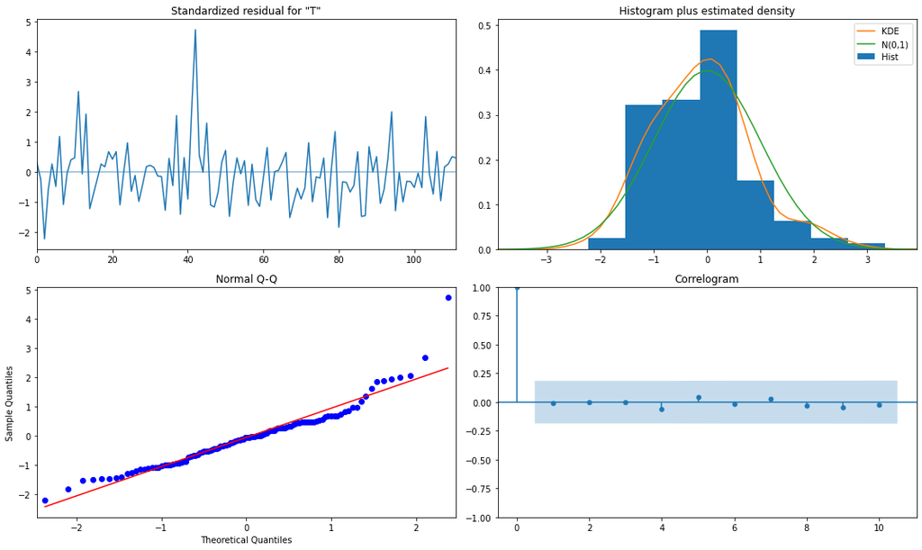

```python
results.plot_diagnostics(figsize=(15, 9))
plt.show()
```

### Results analysis

From the graphs above you can see the model fit the data reasonably.

#### Normal Q-Q

The red line traced the data points appropriately which is a good sign, though you can see some points don't exactly fit the line to the left and particularly at the end of the line.

#### Correlogram

None of the points in the correlogram are outside of the light blue area which is a good sign. The first one is just the first observation so it correlates with itself and will always be very high in any graph.

#### Histogram

Here the green line is just a standard distribution line for reference. The bars represent the distribution of the data by lags defined by the model. Finally the orange line is how the model tried to fit a distribution to the data. You can see the orange line tends to the right at its highest point which fits better with the distribution of the data, as the blue bars are higher there.

## Forecasting

Here I'll try to forecast average delay duration for the end of January (Starting from 20-01-2016).

```python
pred = results.get_prediction(start=pd.to_datetime('2016-01-20 05:28:00'), dynamic=False)
pred_ci = pred.conf_int()
```

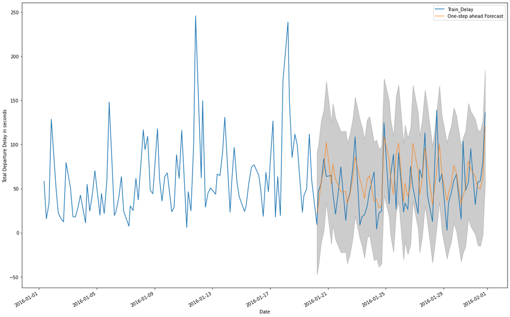

```python
ax = dfGroupie['2016-01-01 06:44:00':].plot(label='observed', figsize=(16, 10))
pred.predicted_mean.plot(ax=ax, label='One-step ahead Forecast', alpha=.7)

ax.fill_between(pred_ci.index,
                pred_ci.iloc[:, 0],
                pred_ci.iloc[:, 1], color='k', alpha=.2)

ax.set_xlabel('Date')
ax.set_ylabel('Total Departure Delay in seconds')
plt.legend()

plt.show()
```

### Forecasting graph analysis

Above you can see a graph showing average train delay in seconds on the y axis, plotted over time for January. You can see that though the lines are very spiky, they actually only ever go from 0 to 250 seconds.

250 seconds being 4 minutes 10 seconds, we will be forecasting very small and likely unimpactful delays. This is probably caused by the data imbalance, taking an average delay for a given time period is likely to trend to very low delays as only a very small percentage of trains ever departs more than 5 minutes late.

#### Trends

Above you can see the forecast follows previously observed trends as the orange line is very close to the blue one. It peaks when the blue one peaks, but does skip some peaks when the blue line is very spiky.

It follows the general trend well however the grey area shows it has a high error margin, even going into negative values despite none of the values ever being negative.

#### Negative Error

For trains the delay being negative means it left early and so it happens almost never, but the model does not know this, it only 'sees' decimal values and their trends over time.

### Mean squared error calculation

Here we calculate the mean squared error to measure the error margin using actual numbers.

```python
delay_forecasted = pred.predicted_mean
delay_truth = dfGroupie['2016-01-20 05:28:00':]
delay_truth = delay_truth.squeeze()

# Compute the mean square error
mse = ((delay_forecasted - delay_truth) ** 2).mean()

print('The Mean Squared Error of our forecasts is {}'.format(round(mse, 2)))
```

```
The Mean Squared Error of our forecasts is 800.79
```

Well the average squared error is 800.79 which seems quite, however this does not tell us anything real so let's calculate its square root now.

```python
math.sqrt(mse)
```

```
28.298214120740564
```

### Error Margin conclusion

Looking at its square root, on average this model will have an error margin of just 28.29 seconds. For a train's delay this is effectively nothing, so this error is practically negligible.

If we look at the forecasting graph again, such a small error margin makes sense as we're working with very small delays anyway.

```python
pred_dynamic = results.get_prediction(start=pd.to_datetime('2016-01-20 05:28:00'), dynamic=True, full_results=True)
pred_dynamic_ci = pred_dynamic.conf_int()
```

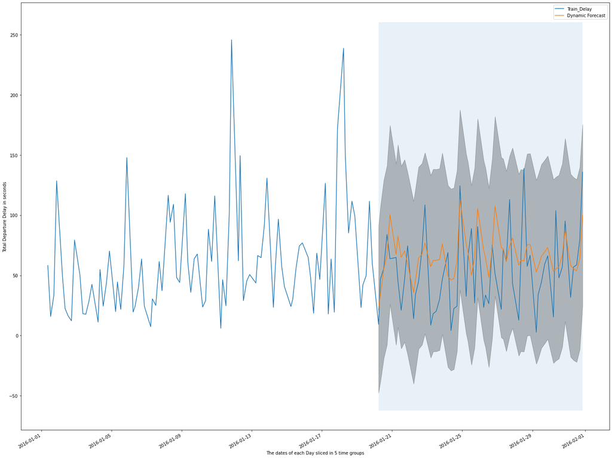

```python
ax = dfGroupie['2016-01-01 06:44:00':].plot(label='observed', figsize=(20, 15))
pred_dynamic.predicted_mean.plot(label='Dynamic Forecast', ax=ax)

ax.fill_between(pred_dynamic_ci.index,
                pred_dynamic_ci.iloc[:, 0],
                pred_dynamic_ci.iloc[:, 1], color='k', alpha=.25)

ax.fill_betweenx(ax.get_ylim(), pd.to_datetime('2016-01-20 05:28:00'), dfGroupie.index[-1],
                 alpha=.1, zorder=-1)

ax.set_xlabel('The dates of each Day sliced in 5 time groups')
ax.set_ylabel('Total Departure Delay in seconds')

plt.legend()
plt.show()
```

### Dynamic Forecasting Graph

Here we can see the dynamic forecasting graph fits an orange line to the data reasonably just like in the previous One Step Ahead forecasting. It roughly follows the peaks in the data though it takes quite a few shortcuts.

It is to be expected that trying to predict more than just the very next step of a trend will be less accurate and we can see this as well. It follows the line less accurately than in the previous forecasting graph.

```python
# Extract the predicted and true values of our time series
delay_forecasted = pred_dynamic.predicted_mean
delay_truth = dfGroupie['2016-01-20 05:28:00':]
delay_truth = delay_truth.squeeze()

# Compute the mean square error
mse = ((delay_forecasted - delay_truth) ** 2).mean()
print('The Mean Squared Error of our forecasts is {}'.format(round(mse, 2)))
```

```
The Mean Squared Error of our forecasts is 938.43
```

```python
math.sqrt(mse)
```

```
30.63372585025354
```

### Error Margin conclusion

Looking at the calculations, on average this model will have an error margin of just 30.63 seconds. Despite being slightly less accurate this error is still negligible.

# Conclusion

Using this model we can predict the average delay of a specific part of a future day with a negligible error.

However many issues prevent us from making actual use of this model:

The data is unrepresentative of the real world:

- The data imbalance caused by almost no train ever departing with a delay of 5 minutes or later, means the model will simply never predict a huge delay.
- The data simply being out of date. 2016 train data is unlikely to be representative of the train infrastructure in 2022

Even if we had the data of 2022 it would likely still be imbalanced due to a lack of large delay data.

Taking the average delay duration per time group makes our model more accurate but is not very helpful. Particularly it cannot predict the large delays that actually impact travel.

Of course were we to try to predict large delays, we would quickly find that we lacked enough data for this, as the vast majority of trains simply don't have a very big delay.

## Go or No Go

Sadly due to the reasons above we simply cannot trust these resuts enough for implementation.